# Diagnóstico de valores extremos em dados multivariados

Uma das maneiras mais comuns de se observar valores extremos (*outliers*) em nossos dados é usar o gráfico de [boxplot](https://pt.wikipedia.org/wiki/Diagrama_de_caixa) em cada variável de interesse (veja no link como o boxplot é usado para classificar valores extremos).

Entretanto, quando temos dados multivariados é interessante observar os valores extremos de maneira conjunta, isto é, levando em consideração todas as variáveis dos dados. Neste caso, os boxplots univariados não nos servem mais[^1]. Detectar valores extremos em observações univariadas é diferente de detectá-los de maneira multivariada e o que era um *outlier* em uma variável pode não ser mais num contexo multivariado e vice-versa.

Neste roteiro, apresento os **boxplots bivariados** do pacote `MVA`, descritos em Everitt and Hothorn (2011) e o uso da **Distância de Mahalanobis** de cada observação ao centróide dos dados para diagnóstico de valores extremos.

# Boxplots em um exemplo bivariado

Vamos usar um exemplo com apenas duas variáveis para facilitar a inspeção visual.

Escolhemos duas variáveis do conjunto de dados `swiss` do pacote `datasets`[^2] e vamos primeiro inspecioná-las separadamente com os boxplots univariados.

```r
# para determinar as observações outiers a serem nomeadas no plot
out <- function(x) {
  return(x < quantile(x, 0.25) - 1.5 * IQR(x) | x > quantile(x, 0.75) + 1.5 * IQR(x))
}
# OBS: é o critério usado na identificação dos oultiers nos boxplots
```

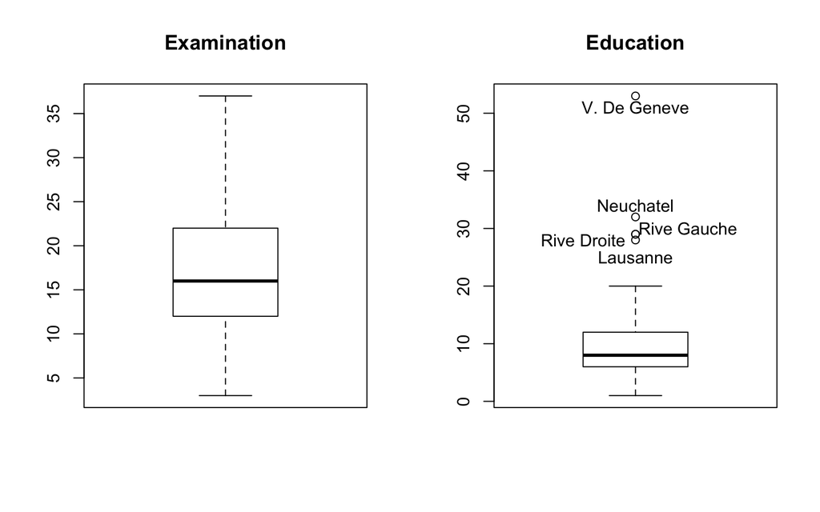

```r
par(mfrow=c(1,2))
boxplot(swiss$Examination, main = "Examination")
boxplot(swiss$Education, main = "Education")
text(x=c(1,1,1,0.8,1.2),
           y=swiss[out(swiss[,4]),4]-c(3,-2,2,1,-1),
           label= rownames(swiss[out(swiss[,4]),]))
par(mfrow=c(1,1))
```

Para `Examination` não encontramos outliers segundo o método do boxplot, mas para `Education` temos 5 valores extremos.

Vamos agora desenhar um **boxplot bivariado** conforme Everitt and Hothorn (2011). Os boxplots bivariados são baseados nos cálculos “robustos” das medidas de locação, escala e correlação e consiste em um par de elipses concêntricas, uma das quais inclui 50% dos dados e a outra que delinea o limite dos dados e deixa de fora os possíveis *outliers*. Também são desenhadas linhas de regressão de x em y e de y em x, com sua interseção mostrando o parâmetro de locação (média das duas variáveis). O ângulo entre as linhas de regressão serão tão pequenos quanto maior for a correlação entre as variáveis.

Vamos usar a função `bvbox` do pacote `MVA` que acompanha o livro de Everitt and Hothorn (2011), para observar a relação entre as variáveis.

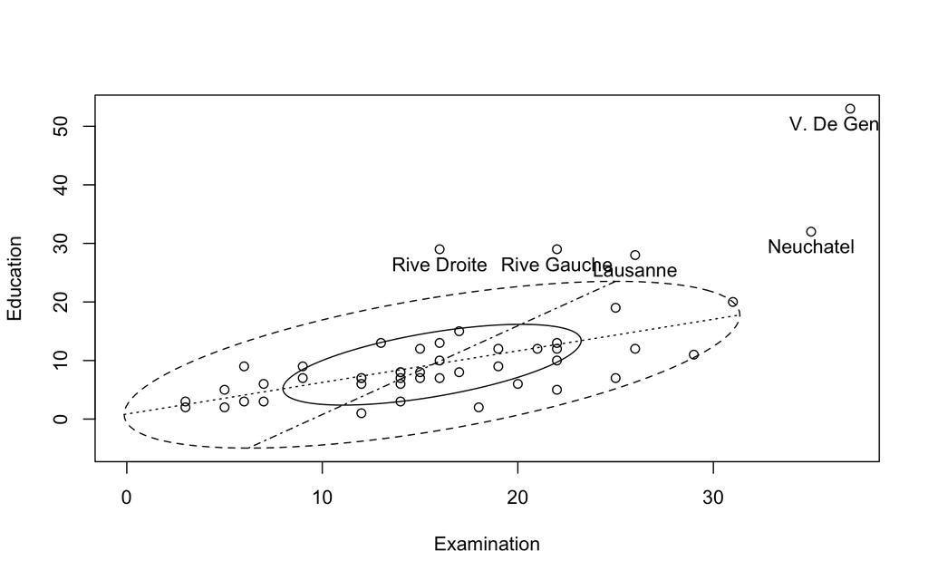

```r
library(MVA)
bvbox(swiss[,c(3,4)], xlab = colnames(swiss)[3], ylab = colnames(swiss)[4])
text(x = swiss[out(swiss[,4]),3], y = swiss[out(swiss[,4]),4]-2.5,
     rownames(swiss[out(swiss[,4]),]))
```

No boxplot bivariado, detectamos os mesmos *outliers* encontrados apenas em `Education`.

A desvantagem dos boxplots bivariados é que eles avaliam os outliers apenas para duas variáveis por vez e geralmente temos mais do que duas variáveis nos nossos dados. A seguir veremos uma forma mais geral de se avaliar os valores extremos multivariados.

# Usando a distância de Mahalanobis

A **distância de Mahalanobis** ($D^2_M$) é uma medida de distância entre as observações (unidades amostrais) e pode também ser usada para medir a distância entre uma única observação multivariada e o centro da população (multivariado não se esqueça), da qual esta esta observação vem (Manly and Navarro Alberto (2017)). No nosso caso, vamos calcular a distância da observação ao centróide da distribuição dos dados.

O [cálculo da distância de Mahalanobis](https://en.wikipedia.org/wiki/Mahalanobis_distance) leva em consideração a correlação entre as variáveis, e seu valor $D^2_M$ pode ser pensado como um resíduo multivariado para a observação $x$. $D^2_M$ é uma medida de quão longe a obervação $x$ está do centro da distribuição de todos os valores, levando em consideração todas as variáveis consideradas e suas covariâncias (Manly and Navarro Alberto (2017)). Um valor alto de $D^2_M$ para a observação $x$ pode indicar um possível *outlier* multivariado, se excluímos a possibilidade de erro de digitação/registro ou que a observação seja de outra distribuição.

Vamos calcular $D^2_M$ para cada observação dos dados apresentados acima, e plotar estas distâncias. Um critério para o diagnóstico dos outliers a partir da distância de Mahalanobis é verificar se a distância calculada está acima de um limiar $c^2$, que nada mais é do que a estatística do Qui-quadrado ($\chi^2$) calculada para um valor de probabilidade escolhido. No exemplo abaixo, eu escolhi um $\alpha$ de 10% e fui na distribuição de ($\chi^2$) com 2 graus de liberdade (g.l. = número de variáveis sendo analisadas) saber qual é o quantil e desenhei a linha pontilhada no gráfico com este valor.

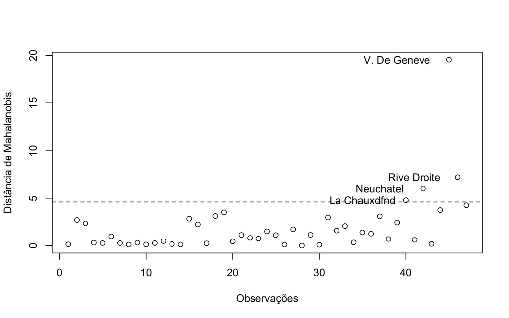

```r
maha <- mahalanobis(swiss[,3:4], # dados
                    center = colMeans(swiss[,3:4]), # médias das variáveis
                    cov = cov(swiss[,3:4])) # matriz de covariâncias

#calculando o cˆ2 para delimitar o limiar
quant <- qchisq(0.1, 2, lower.tail = F)

plot(1:length(maha), maha, xlab = "Observações",
     ylab= "Distância de Mahalanobis")
abline(h=quant, lty=2)

out <- maha[maha>quant]
text(c(42,44,46,48)-7, out, names(out))
```

Desta forma, para o critério usando a distância de Mahalanobis, 4 observações foram consideradas *outliers* bivariados. Este critério está dizendo que as 4 observações com maior distância tem pouca probabilidade de serem advindas da população com distribuição normal bivariada assumida nos dados.

# Diagnosticando *outliers* multivariados

Agora vamos expandir nosso exemplo usando todas as variáveis existentes nos dados `swiss`. Aqui eu não vou fazer os boxplots bivariados (você já sabe como faz), mas quero apenas mostrar o plot da distância de Mahalanobis para ver se, com mais variáveis, temos diferentes outliers detectados.

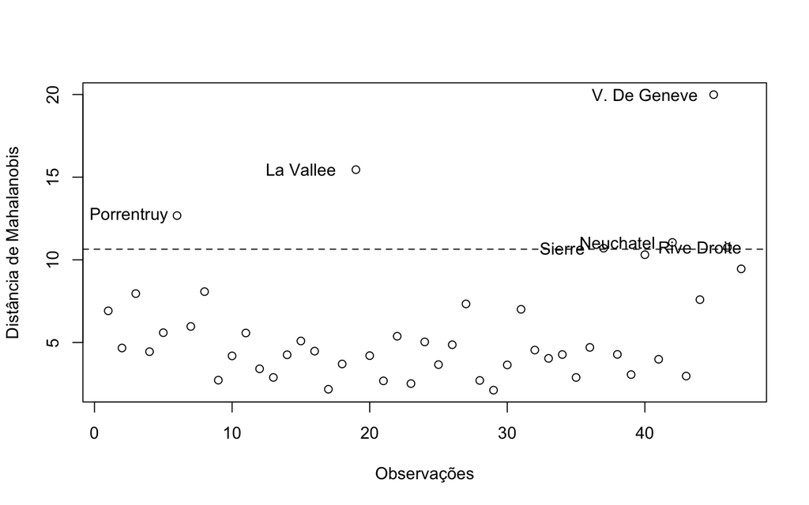

```r
maha2 <- mahalanobis(swiss, center = colMeans(swiss), cov = cov(swiss))

# para calcular o cˆ2, lembre-se que os graus de liberdade agora são 6
quant2 <- qchisq(0.90, 6) # outra forma de pegar o quantil do chi-quadrado

plot(1:length(maha2), maha2, xlab = "Observações",
     ylab= "Distância de Mahalanobis")
abline(h=quant2, lty=2)

out2 <- maha2[maha2>quant2]
text(c(2.5,15,34,38,40,44), out2, names(out2))
```

Com mais variáveis, tivemos diferentes observações detectadas como *outliers* e por isso a importância de se analisar os valores extremos em dados multivariados de maneira conjunta!

## Usando pacote `MVN`

O pacote `MVN` possui uma função que também detecta *outliers* multivariados a partir da **distância de Mahalanobis**. Esse pacote usa dois métodos *robustos* (ver detales [aqui](https://pdfs.semanticscholar.org/5508/25b2681f1cc067c66df6ddbd62c74b441869.pdf?_ga=2.25175998.286279602.1517010562-1528935492.1517010562)) para calcular a distância de Mahalanobis (a distância de Mahalanobis Robusta e a Ajustada), e portanto dão resultados um pouco diferentes do que fizemos anteriormente.

Outra diferença é que resultado é apresentado em um gráfico quantil-quantil (*qqplot*), com um dos eixos sendo a $D^2_M$ e o outro os quantis de uma distribuição $\chi^2$.

```r
library(MVN)

outliers <- mvOutlier(swiss, alpha=0.90, method="quan")
# tente method="adj.quan"
```

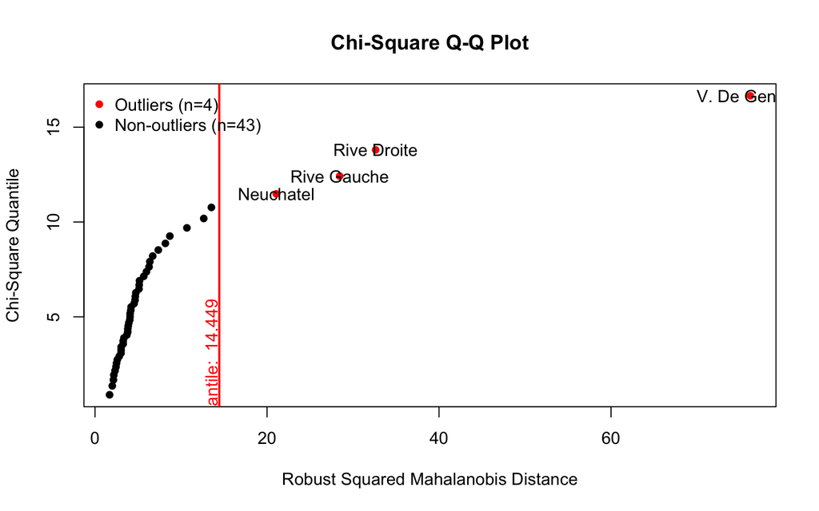

# Observações finais

Vale lembrar que estes valores extremos não necessariamente são erros de digitação/medida, mas podem ser valores reais, porém pouco prováveis. A decisão sobre o que fazer com estes *possíveis outliers* detectados depende muito da natureza dos dados, do contexto de coleta dos dados e do tipo de análise a ser conduzida.

Uma sugestão feita por Manly and Navarro Alberto (2017) é a de conduzir análises com e sem os valores extremos e comparar os resultados. Se a conclusão é a mesma, então não há problemas. Mas se as conclusões dependem muito dos *outliers*, então é preciso muito mais cuidado com as decisões a serem tomadas.

# Referências

Everitt, B, and T Hothorn. 2011. *An Introduction to Applied Multivariate Analysis with R*.

Manly, Bryan F. J., and Jorge A. Navarro Alberto. 2017. *Multivariate Statistical Methods: A Primer*. Fourth edition. Boca Raton: CRC Press.

[^1]: eles também não servem se a quantidade de dados for muito grande, veja [esse roteiro](http://rpubs.com/melinatarituba/351028) sobre gráficos alternativos aos boxplots nessa situação.
[^2]: que não precisa ser carregado porque já vem junto como R base.

Melina de Souza Leite http://melinaleite.weebly.com/

05 de Fevereiro de 2018